# week_2_Use_tidyverse_package_student

2023-03-10

#1. Tidyverse 패키지 및 간단한 사용법

## ggplot2, for data visualization.

## dplyr, for data manipulation.

## purrr, for functional programing.

## tibble, for tibbles, a mordern re-imagining of data frames.

## forcats, for factors.

```r
# install.packages("tidyverse")
library(tidyverse)
```

코드가 길어지면 이해하기 어려운 한계가 존재

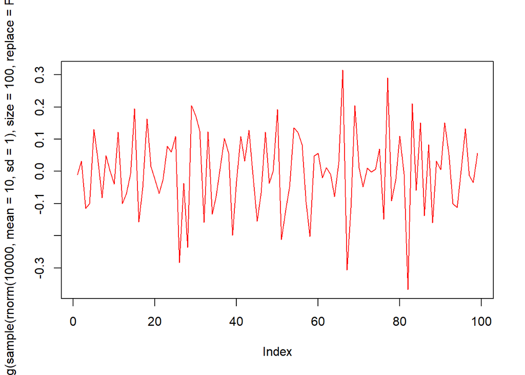

```r
plot(diff(log(sample(rnorm(10000, mean = 10, sd = 1), size = 100,
                     replace = FALSE))), col = "red", type = "l")
```

#2. 파이프 연산자(%>%)를 통한 코드의 직관화

순차적 흐름으로 코드를 이해할 수 있음 중간 변수들을 계속해서 Object로 할당할 필요가 없음

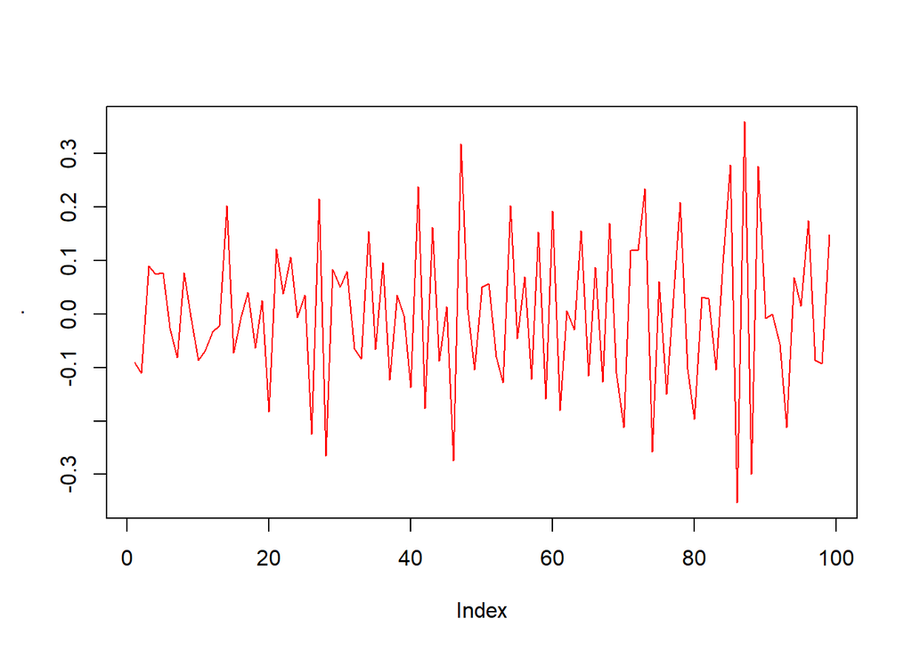

```r
rnorm(10000, mean = 10, sd = 1) %>%
  sample(size = 100, replace = FALSE) %>%
  log() %>%
  diff() %>%
  plot(col = "red", type = "l")
```

#3. Flight 데이터의 파이프 연산자 예시

사용할 데이터셋은 뉴욕시에서 2013년에 출발한 336,776개의 모든 항공편이 포함된 데이터 (nycflights13패키지의 flights 데이터셋)

```r
#install.packages("nycflights13")
library(nycflights13)
nrow(flights)
```

```
## [1] 336776
```

```r
head(flights)
```

```
## # A tibble: 6 × 19
##    year month   day dep_time sched_dep…¹ dep_d…² arr_t…³ sched…⁴ arr_d…⁵ carrier
##   <int> <int> <int>    <int>       <int>   <dbl>   <int>   <int>   <dbl> <chr>
## 1  2013     1     1      517         515       2     830     819      11 UA
## 2  2013     1     1      533         529       4     850     830      20 UA
## 3  2013     1     1      542         540       2     923     850      33 AA
## 4  2013     1     1      544         545      -1    1004    1022     -18 B6
## 5  2013     1     1      554         600      -6     812     837     -25 DL
## 6  2013     1     1      554         558      -4     740     728      12 UA
## # … with 9 more variables: flight <int>, tailnum <chr>, origin <chr>,
## #   dest <chr>, air_time <dbl>, distance <dbl>, hour <dbl>, minute <dbl>,
## #   time_hour <dttm>, and abbreviated variable names ¹sched_dep_time,
## #   ²dep_delay, ³arr_time, ⁴sched_arr_time, ⁵arr_delay
```

flights data를 선택 후, group_by 한 후, summarise를 수행 각 function의 기능이 무엇인지 몰라도 대략적인 흐름을 파악할 수 있음

```r
flights %>%
  group_by(year, month, day) %>%
  summarise(delay = mean(dep_delay, na.rm = TRUE))
```

```
## # A tibble: 365 × 4
## # Groups:   year, month [12]
##     year month   day delay
##    <int> <int> <int> <dbl>
##  1  2013     1     1 11.5
##  2  2013     1     2 13.9
##  3  2013     1     3 11.0
##  4  2013     1     4  8.95
##  5  2013     1     5  5.73
##  6  2013     1     6  7.15
##  7  2013     1     7  5.42
##  8  2013     1     8  2.55
##  9  2013     1     9  2.28
## 10  2013     1    10  2.84
## # … with 355 more rows
```

```r
mean_delay_by_day <- flights %>%
  group_by(year, month, day) %>%
  summarise(delay = mean(dep_delay, na.rm = TRUE))
```

#4. dplyr 패키지에 포함된 유용한 명령어들

##4-1 select(): 열방향 선택

데이터에서 특정 컬럼을 선택하고 싶을 때 사용. 선언된 순서대로 컬럼을 정렬함

```r
flights %>% select(year, month, day)
```

```
## # A tibble: 336,776 × 3
##     year month   day
##    <int> <int> <int>
##  1  2013     1     1
##  2  2013     1     1
##  3  2013     1     1
##  4  2013     1     1
##  5  2013     1     1
##  6  2013     1     1
##  7  2013     1     1
##  8  2013     1     1
##  9  2013     1     1
## 10  2013     1     1
## # … with 336,766 more rows
```

```r
# 컬럼에 띄어쓰기가 존재할 때
flights$'not use' <- 0

#컬럼이름에 되도록 띄어쓰기는 사용하지 맙시다
flights %>% select('not use')
```

```
## # A tibble: 336,776 × 1
##    `not use`
##        <dbl>
##  1         0
##  2         0
##  3         0
##  4         0
##  5         0
##  6         0
##  7         0
##  8         0
##  9         0
## 10         0
## # … with 336,766 more rows
```

##4-2 mutate(): 새로운 컬럼을 만들거나 계산하고 싶을때

편의성을 위해 일부 데이터만 추출

```r
flight_sample <- flights %>% select(year:day, ends_with("delay"), distance, air_time)
flight_sample
```

```
## # A tibble: 336,776 × 7
##     year month   day dep_delay arr_delay distance air_time
##    <int> <int> <int>     <dbl>     <dbl>    <dbl>    <dbl>
##  1  2013     1     1         2        11     1400      227
##  2  2013     1     1         4        20     1416      227
##  3  2013     1     1         2        33     1089      160
##  4  2013     1     1        -1       -18     1576      183
##  5  2013     1     1        -6       -25      762      116
##  6  2013     1     1        -4        12      719      150
##  7  2013     1     1        -5        19     1065      158
##  8  2013     1     1        -3       -14      229       53
##  9  2013     1     1        -3        -8      944      140
## 10  2013     1     1        -2         8      733      138
## # … with 336,766 more rows
```

각 컬럼간의 계산으로 새로운 열(column)을 만듦

```r
flight_sample %>% mutate(net_delay = arr_delay - dep_delay,
                         speed = distance/air_time * 60)
```

```
## # A tibble: 336,776 × 9
##     year month   day dep_delay arr_delay distance air_time net_delay speed
##    <int> <int> <int>     <dbl>     <dbl>    <dbl>    <dbl>     <dbl> <dbl>
##  1  2013     1     1         2        11     1400      227         9  370.
##  2  2013     1     1         4        20     1416      227        16  374.
##  3  2013     1     1         2        33     1089      160        31  408.
##  4  2013     1     1        -1       -18     1576      183       -17  517.
##  5  2013     1     1        -6       -25      762      116       -19  394.
##  6  2013     1     1        -4        12      719      150        16  288.
##  7  2013     1     1        -5        19     1065      158        24  404.
##  8  2013     1     1        -3       -14      229       53       -11  259.
##  9  2013     1     1        -3        -8      944      140        -5  405.
## 10  2013     1     1        -2         8      733      138        10  319.
## # … with 336,766 more rows
```

##4-3 filter(): 행방향으로 조건을 설정

filter()는 데이터 중에 조건에 해당하는 일부 데이터만 필터해서 사용. 논리 연산자와 결합하여 많이 사용.

```r
a <- c(10, 20, 30, 40, 50)
b <- 30

#논리 연산자
a==b
```

```
## [1] FALSE FALSE  TRUE FALSE FALSE
```

```r
a>b
```

```
## [1] FALSE FALSE FALSE  TRUE  TRUE
```

```r
#숫자를 사용한 인덱싱
a[1]
```

```
## [1] 10
```

```r
a[3]
```

```
## [1] 30
```

```r
a[c(1, 3)]
```

```
## [1] 10 30
```

```r
#논리연산자를 사용한 인덱싱
a[a>b]
```

```
## [1] 40 50
```

```r
a[c(4, 5)]
```

```
## [1] 40 50
```

```r
flights %>% filter(month == 1)
```

```
## # A tibble: 27,004 × 20
##     year month   day dep_time sched_de…¹ dep_d…² arr_t…³ sched…⁴ arr_d…⁵ carrier
##    <int> <int> <int>    <int>      <int>   <dbl>   <int>   <int>   <dbl> <chr>
##  1  2013     1     1      517        515       2     830     819      11 UA
##  2  2013     1     1      533        529       4     850     830      20 UA
##  3  2013     1     1      542        540       2     923     850      33 AA
##  4  2013     1     1      544        545      -1    1004    1022     -18 B6
##  5  2013     1     1      554        600      -6     812     837     -25 DL
##  6  2013     1     1      554        558      -4     740     728      12 UA
##  7  2013     1     1      555        600      -5     913     854      19 B6
##  8  2013     1     1      557        600      -3     709     723     -14 EV
##  9  2013     1     1      557        600      -3     838     846      -8 B6
## 10  2013     1     1      558        600      -2     753     745       8 AA
## # … with 26,994 more rows, 10 more variables: flight <int>, tailnum <chr>,
## #   origin <chr>, dest <chr>, air_time <dbl>, distance <dbl>, hour <dbl>,
## #   minute <dbl>, time_hour <dttm>, `not use` <dbl>, and abbreviated variable
## #   names ¹sched_dep_time, ²dep_delay, ³arr_time, ⁴sched_arr_time, ⁵arr_delay
```

##4-4 bind_raws()

두 데이터를 행방향으로 묶음 데이터를 아래로 붙임

filter()를 사용한 subset 추출

```r
jan <- flights %>% filter(month == 1)
feb <- flights %>% filter(month == 2)

janfeb <- bind_rows(jan, feb)
janfeb
```

```
## # A tibble: 51,955 × 20
##     year month   day dep_time sched_de…¹ dep_d…² arr_t…³ sched…⁴ arr_d…⁵ carrier
##    <int> <int> <int>    <int>      <int>   <dbl>   <int>   <int>   <dbl> <chr>
##  1  2013     1     1      517        515       2     830     819      11 UA
##  2  2013     1     1      533        529       4     850     830      20 UA
##  3  2013     1     1      542        540       2     923     850      33 AA
##  4  2013     1     1      544        545      -1    1004    1022     -18 B6
##  5  2013     1     1      554        600      -6     812     837     -25 DL
##  6  2013     1     1      554        558      -4     740     728      12 UA
##  7  2013     1     1      555        600      -5     913     854      19 B6
##  8  2013     1     1      557        600      -3     709     723     -14 EV
##  9  2013     1     1      557        600      -3     838     846      -8 B6
## 10  2013     1     1      558        600      -2     753     745       8 AA
## # … with 51,945 more rows, 10 more variables: flight <int>, tailnum <chr>,
## #   origin <chr>, dest <chr>, air_time <dbl>, distance <dbl>, hour <dbl>,
## #   minute <dbl>, time_hour <dttm>, `not use` <dbl>, and abbreviated variable
## #   names ¹sched_dep_time, ²dep_delay, ³arr_time, ⁴sched_arr_time, ⁵arr_delay
```

```r
flights %>% filter(month %in% c(1, 2))
```

```
## # A tibble: 51,955 × 20
##     year month   day dep_time sched_de…¹ dep_d…² arr_t…³ sched…⁴ arr_d…⁵ carrier
##    <int> <int> <int>    <int>      <int>   <dbl>   <int>   <int>   <dbl> <chr>
##  1  2013     1     1      517        515       2     830     819      11 UA
##  2  2013     1     1      533        529       4     850     830      20 UA
##  3  2013     1     1      542        540       2     923     850      33 AA
##  4  2013     1     1      544        545      -1    1004    1022     -18 B6
##  5  2013     1     1      554        600      -6     812     837     -25 DL
##  6  2013     1     1      554        558      -4     740     728      12 UA
##  7  2013     1     1      555        600      -5     913     854      19 B6
##  8  2013     1     1      557        600      -3     709     723     -14 EV
##  9  2013     1     1      557        600      -3     838     846      -8 B6
## 10  2013     1     1      558        600      -2     753     745       8 AA
## # … with 51,945 more rows, 10 more variables: flight <int>, tailnum <chr>,
## #   origin <chr>, dest <chr>, air_time <dbl>, distance <dbl>, hour <dbl>,
## #   minute <dbl>, time_hour <dttm>, `not use` <dbl>, and abbreviated variable
## #   names ¹sched_dep_time, ²dep_delay, ³arr_time, ⁴sched_arr_time, ⁵arr_delay
```

##4-5 arrange(): 데이터 정렬

지정되는 컬럼 기준으로 어름차순으로 정렬

```r
#오름차순 정렬
flights %>% arrange(dep_delay)
```

```
## # A tibble: 336,776 × 20
##     year month   day dep_time sched_de…¹ dep_d…² arr_t…³ sched…⁴ arr_d…⁵ carrier
##    <int> <int> <int>    <int>      <int>   <dbl>   <int>   <int>   <dbl> <chr>
##  1  2013    12     7     2040       2123     -43      40    2352      48 B6
##  2  2013     2     3     2022       2055     -33    2240    2338     -58 DL
##  3  2013    11    10     1408       1440     -32    1549    1559     -10 EV
##  4  2013     1    11     1900       1930     -30    2233    2243     -10 DL
##  5  2013     1    29     1703       1730     -27    1947    1957     -10 F9
##  6  2013     8     9      729        755     -26    1002     955       7 MQ
##  7  2013    10    23     1907       1932     -25    2143    2143       0 EV
##  8  2013     3    30     2030       2055     -25    2213    2250     -37 MQ
##  9  2013     3     2     1431       1455     -24    1601    1631     -30 9E
## 10  2013     5     5      934        958     -24    1225    1309     -44 B6
## # … with 336,766 more rows, 10 more variables: flight <int>, tailnum <chr>,
## #   origin <chr>, dest <chr>, air_time <dbl>, distance <dbl>, hour <dbl>,
## #   minute <dbl>, time_hour <dttm>, `not use` <dbl>, and abbreviated variable
## #   names ¹sched_dep_time, ²dep_delay, ³arr_time, ⁴sched_arr_time, ⁵arr_delay
```

```r
#내림차순 정렬
flights %>% arrange(-dep_delay)
```

```
## # A tibble: 336,776 × 20
##     year month   day dep_time sched_de…¹ dep_d…² arr_t…³ sched…⁴ arr_d…⁵ carrier
##    <int> <int> <int>    <int>      <int>   <dbl>   <int>   <int>   <dbl> <chr>
##  1  2013     1     9      641        900    1301    1242    1530    1272 HA
##  2  2013     6    15     1432       1935    1137    1607    2120    1127 MQ
##  3  2013     1    10     1121       1635    1126    1239    1810    1109 MQ
##  4  2013     9    20     1139       1845    1014    1457    2210    1007 AA
##  5  2013     7    22      845       1600    1005    1044    1815     989 MQ
##  6  2013     4    10     1100       1900     960    1342    2211     931 DL
##  7  2013     3    17     2321        810     911     135    1020     915 DL
##  8  2013     6    27      959       1900     899    1236    2226     850 DL
##  9  2013     7    22     2257        759     898     121    1026     895 DL
## 10  2013    12     5      756       1700     896    1058    2020     878 AA
## # … with 336,766 more rows, 10 more variables: flight <int>, tailnum <chr>,
## #   origin <chr>, dest <chr>, air_time <dbl>, distance <dbl>, hour <dbl>,
## #   minute <dbl>, time_hour <dttm>, `not use` <dbl>, and abbreviated variable
## #   names ¹sched_dep_time, ²dep_delay, ³arr_time, ⁴sched_arr_time, ⁵arr_delay
```

##4-6 group_by() & summarise(): 그룹별로 계산을 수행

그룹별로 통계치를 뽑거나 특정 계산을 수행하고 싶은 경우

```r
#그룹을 하지 않았을 때
flights %>%
  summarise(mean_dep_delay = mean(dep_delay, na.rm = T),
            count = n())
```

```
## # A tibble: 1 × 2
##   mean_dep_delay  count
##            <dbl>  <int>
## 1           12.6 336776
```

```r
flights %>%
  group_by(month) %>%
  summarise(mean_dep_delay = mean(dep_delay, na.rm = T),
            count = n())
```

```
## # A tibble: 12 × 3
##    month mean_dep_delay count
##    <int>          <dbl> <int>
##  1     1          10.0  27004
##  2     2          10.8  24951
##  3     3          13.2  28834
##  4     4          13.9  28330
##  5     5          13.0  28796
##  6     6          20.8  28243
##  7     7          21.7  29425
##  8     8          12.6  29327
##  9     9           6.72 27574
## 10    10           6.24 28889
## 11    11           5.44 27268
## 12    12          16.6  28135
```

##4-7 left_join()

```r
#특정 컬럼만 추출
flight_sample <- flights %>% select(year:day, origin, carrier)
flight_sample
```

```
## # A tibble: 336,776 × 5
##     year month   day origin carrier
##    <int> <int> <int> <chr>  <chr>
##  1  2013     1     1 EWR    UA
##  2  2013     1     1 LGA    UA
##  3  2013     1     1 JFK    AA
##  4  2013     1     1 JFK    B6
##  5  2013     1     1 LGA    DL
##  6  2013     1     1 EWR    UA
##  7  2013     1     1 EWR    B6
##  8  2013     1     1 LGA    EV
##  9  2013     1     1 JFK    B6
## 10  2013     1     1 LGA    AA
## # … with 336,766 more rows
```

```r
# 항공사 이름
airlines
```

```
## # A tibble: 16 × 2
##    carrier name
##    <chr>   <chr>
##  1 9E      Endeavor Air Inc.
##  2 AA      American Airlines Inc.
##  3 AS      Alaska Airlines Inc.
##  4 B6      JetBlue Airways
##  5 DL      Delta Air Lines Inc.
##  6 EV      ExpressJet Airlines Inc.
##  7 F9      Frontier Airlines Inc.
##  8 FL      AirTran Airways Corporation
##  9 HA      Hawaiian Airlines Inc.
## 10 MQ      Envoy Air
## 11 OO      SkyWest Airlines Inc.
## 12 UA      United Air Lines Inc.
## 13 US      US Airways Inc.
## 14 VX      Virgin America
## 15 WN      Southwest Airlines Co.
## 16 YV      Mesa Airlines Inc.
```

두 데이터를 특정한 key value를 기준으로 좌우로 붙이고 싶을 때 left_join()을 사용

```r
flight_sample %>% left_join(airlines, by = "carrier")
```

```
## # A tibble: 336,776 × 6
##     year month   day origin carrier name
##    <int> <int> <int> <chr>  <chr>   <chr>
##  1  2013     1     1 EWR    UA      United Air Lines Inc.
##  2  2013     1     1 LGA    UA      United Air Lines Inc.
##  3  2013     1     1 JFK    AA      American Airlines Inc.
##  4  2013     1     1 JFK    B6      JetBlue Airways
##  5  2013     1     1 LGA    DL      Delta Air Lines Inc.
##  6  2013     1     1 EWR    UA      United Air Lines Inc.
##  7  2013     1     1 EWR    B6      JetBlue Airways
##  8  2013     1     1 LGA    EV      ExpressJet Airlines Inc.
##  9  2013     1     1 JFK    B6      JetBlue Airways
## 10  2013     1     1 LGA    AA      American Airlines Inc.
## # … with 336,766 more rows
```

key 값의 컬럼 이름이 다를 경우

```r
colnames(airlines)[1] <- "company_name"

flight_sample %>% left_join(airlines, by = c("carrier" = "company_name"))
```

```
## # A tibble: 336,776 × 6
##     year month   day origin carrier name
##    <int> <int> <int> <chr>  <chr>   <chr>
##  1  2013     1     1 EWR    UA      United Air Lines Inc.
##  2  2013     1     1 LGA    UA      United Air Lines Inc.
##  3  2013     1     1 JFK    AA      American Airlines Inc.
##  4  2013     1     1 JFK    B6      JetBlue Airways
##  5  2013     1     1 LGA    DL      Delta Air Lines Inc.
##  6  2013     1     1 EWR    UA      United Air Lines Inc.
##  7  2013     1     1 EWR    B6      JetBlue Airways
##  8  2013     1     1 LGA    EV      ExpressJet Airlines Inc.
##  9  2013     1     1 JFK    B6      JetBlue Airways
## 10  2013     1     1 LGA    AA      American Airlines Inc.
## # … with 336,766 more rows
```